# Welcome to r2resize: In-text resizing for images and tables in Markdown and Quarto documents

Obinna N. Obianom

2022-09-10

# Easily add automatic resizing toolbar for all images and tables in Markdown, Rmarkdown and Quarto documents

## Installation and Library Attachment

The r2resize package is available on CRAN and can be installed as shown below

`install.packages(r2resize)`

Attach library

`library(r2resize)`

## Use

The r2resize can be used within the R Markdown or Quarto document using an R chunk as shown below

`r2resize::add.resizer()`

or by using the available options. An example of how the available options can be used is show below

```r
r2resize::add.resizer(
  theme.color = "black",
  position = "top",
  font.size = "12px",
  font.color = "darkblue",
  tables = TRUE,
  images = TRUE,
  line.color = "orange",
  line.width = 150
)
```

# Images Examples

Elit pellentesque habitant morbi tristique senectus et netus et malesuada. Amet massa vitae tortor condimentum lacinia quis vel eros.

Imperdiet nulla malesuada pellentesque elit eget gravida. Turpis massa sed elementum tempus egestas.

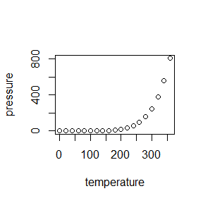

[figure not shown]

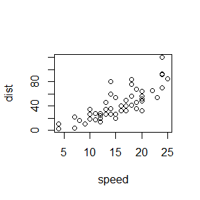

# Table Examples

## Use with dataTable

Libero id faucibus nisl tincidunt. Ultrices tincidunt arcu non sodales neque sodales ut etiam. Ut placerat orci nulla pellentesque dignissim enim sit amet. Tempus quam pellentesque nec nam.

```r
library(DT)
datatable(iris)
```

|  | Sepal.Length | Sepal.Width | Petal.Length | Petal.Width | Species |
| --- | --- | --- | --- | --- | --- |
| 1 | 5.1 | 3.5 | 1.4 | 0.2 | setosa |
| 2 | 4.9 | 3 | 1.4 | 0.2 | setosa |
| 3 | 4.7 | 3.2 | 1.3 | 0.2 | setosa |
| 4 | 4.6 | 3.1 | 1.5 | 0.2 | setosa |
| 5 | 5 | 3.6 | 1.4 | 0.2 | setosa |
| 6 | 5.4 | 3.9 | 1.7 | 0.4 | setosa |
| 7 | 4.6 | 3.4 | 1.4 | 0.3 | setosa |
| 8 | 5 | 3.4 | 1.5 | 0.2 | setosa |
| 9 | 4.4 | 2.9 | 1.4 | 0.2 | setosa |
| 10 | 4.9 | 3.1 | 1.5 | 0.1 | setosa |

[output cut: 140 more lines]

## Regular Markdown Table 1 and 2

Egestas purus viverra accumsan in. Eu ultrices vitae auctor eu augue ut lectus. Leo integer malesuada nunc vel risus commodo.

| Column 1 | Column 2 | Column 3 | Column 4 | Column 5 |
| --- | --- | --- | --- | --- |
| 1 | 23 | 1 | 45 | 6 - 12 |
| 3 | 4 | 5 | NA | 4 - 5.5 |
| 7 | 7 | 5 | 0 | 5 - 34 |

| head1 | head2 | head3 | head4 | head5 |
| --- | --- | --- | --- | --- |
| 1 | 23 | 1 | A | AA |
| 3 | 4 | 5 | B | BB |
| 7 | 7 | 5 | C | CC |

# Full examples and documentation

- https://r2resize.obi.obianom.com